# ONTO Innovation (ONTO) 기업 분석 보고서

Alpha Hunter Hidden Gem Week 20 — 반도체 검사/계측 장비, SEPA 7/7 통과 + AI/HBM 수혜

Author

Alpha Hunter × Chimera AI

Published

May 14, 2026

# 기업 개요

| 항목 | 내용 |
| --- | --- |
| **종목명** | ONTO Innovation, Inc. (ONTO, NYSE) |
| **업종** | Semiconductor Equipment / 공정 검사·계측 장비 |
| **핵심 사업** | 반도체 계측(Metrology), 검사(Inspection), 리소그래피 장비 |
| **시총** | $13.8B (약 20.1조원) |
| **현재가** | $290.76 |
| **PER (TTM/Fwd)** | 42.3x / 29.2x |
| **영업이익률** | 26.7% (Q1 2026) |
| **52주 범위** | $85.95 — $315.87 |
| **SEPA 점수** | **7/7 통과** |

> **핵심 투자 포인트**: 반도체 검사/계측 장비 글로벌 Top 3. Q1 매출 $292M(역대 최고) + 2026 연간 매출 30%+ 성장 전망. AI/HBM/어드밴스드 패키징 메가트렌드의 직접 수혜주. SEPA 7개 조건 모두 충족.

# 1 SEPA 트렌드 템플릿 분석 (Mark Minervini)

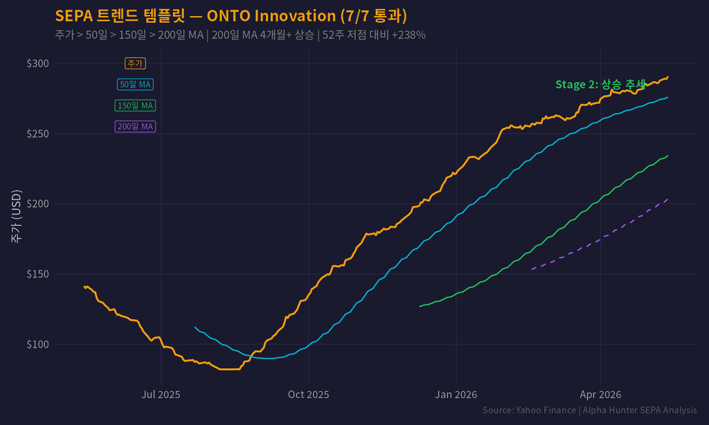

Figure 1: SEPA 트렌드 템플릿 — ONTO 7/7 통과, Stage 2 상승 추세 확인

### 1.0.1 SEPA 7개 조건 체크리스트

[output not shown]

> **SEPA 판정: Stage 2 (상승 추세) — 7/7 통과.** 2025년 8월 $86 바닥 이후 +238% 상승. 52주 고점 $316 대비 -7.9%로 신고가 돌파 임박. 모든 이평선이 정배열.

# 2 왜 지금 ONTO인가?

## 2.1 반도체 검사/계측 — AI 시대의 필수 장비

반도체가 미세화될수록 검사/계측 장비의 중요성이 기하급수적으로 증가한다. ONTO Innovation은 이 구조적 수혜의 중심에 있다:

- **어드밴스드 패키징 (CoWoS/2.5D/3D)**: HBM 적층, 마이크로범프 검사 → Dragonfly G5 시스템
- **선단 노드 (GAA/2nm)**: Gate-All-Around 공정 계측 → Atlas G6 시스템
- **AI 가속기**: NVIDIA GPU, Google TPU, AMD MI 등 AI칩의 공정 제어 수요 폭발

## 2.2 Dragonfly G5 & Atlas G6 — 차세대 성장 엔진

Q1 2026에서 확인된 핵심 성과:

1. **Dragonfly G5**: 주요 2.5D 로직 고객 + HBM 고객에서 퀄리파이 완료
2. **Atlas G6**: 두 번째 로직 고객이 GAA 계측용으로 선정 → 선단 노드 매출 +13%
3. **Semilab 인수**: 재료 분석 사업 인수로 포트폴리오 확대
4. **Rigaku 협업**: 전략적 협력으로 신규 분석 역량 확보

# 3 실적 분석

## 3.1 Q1 2026 — 역대 최고 매출 경신

| 지표 | Q1 2026 | Q4 2025 | QoQ | Q1 2025 | YoY |
| --- | --- | --- | --- | --- | --- |
| **매출** | $292M | $267M | +9.4% | $228M | +28.1% |
| **매출총이익률** | 55.7% | 54.6% | +110bp | 54.0% | +170bp |
| **영업이익률** | 26.7% | 25.2% | +150bp | 22.3% | +440bp |
| **EPS** | $1.42 | $1.26 | +12.7% | $0.95 | +49.5% |

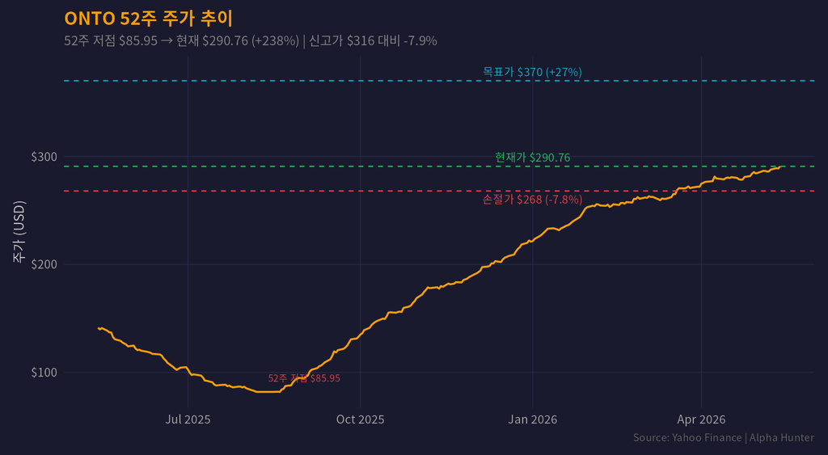

Figure 2: ONTO 52주 주가 추이 — 52주 저점 $86 → 현재 $291 (+238%)

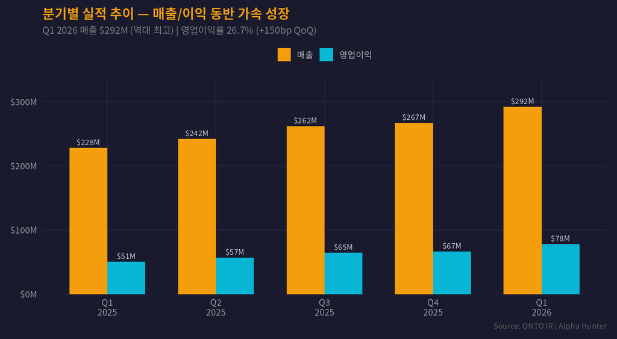

## 3.2 2026 가이던스 — 연간 매출 $1.3B+ 전망

경영진이 제시한 2026 가이던스:

- **Q2 2026**: 매출 $320-330M (QoQ +10~13%)
- **2026 연간**: 매출 $1.3B+ (YoY **+30% 이상**)
- **하반기**: 상반기 대비 최소 15% 추가 성장
- **Q4 영업이익률**: 30%+ 목표

이는 AI/HBM 검사 수요가 구조적으로 확대되고 있음을 의미한다.

# 4 밸류에이션 비교

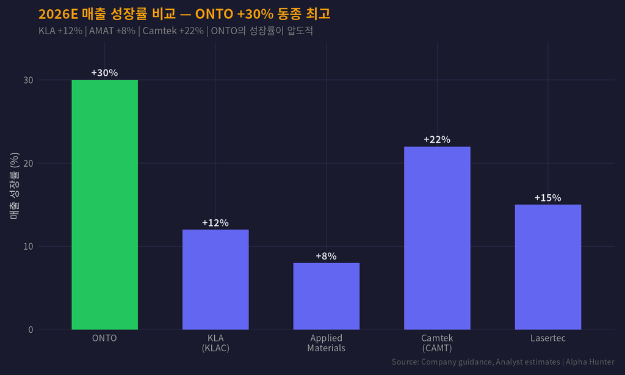

### 4.0.1 Forward PE vs 성장률

| 기업 | Fwd PE | 매출 성장 | OPM | PEG 추정 |
| --- | --- | --- | --- | --- |
| **ONTO** | 29.2x | +30% | 26.7% | ~0.97 |
| KLA | 24.5x | +12% | 40.2% | ~2.0 |
| AMAT | 20.8x | +8% | 28.5% | ~2.6 |
| Camtek | 28.0x | +22% | 25.0% | ~1.3 |
| Lasertec | 35.0x | +15% | 45.0% | ~2.3 |

ONTO의 PEG는 ~1.0으로 성장 대비 가장 합리적인 밸류에이션. KLA와 AMAT은 성장률이 낮은데 프리미엄이 높다.

# 5 워런 버핏 해자 분석

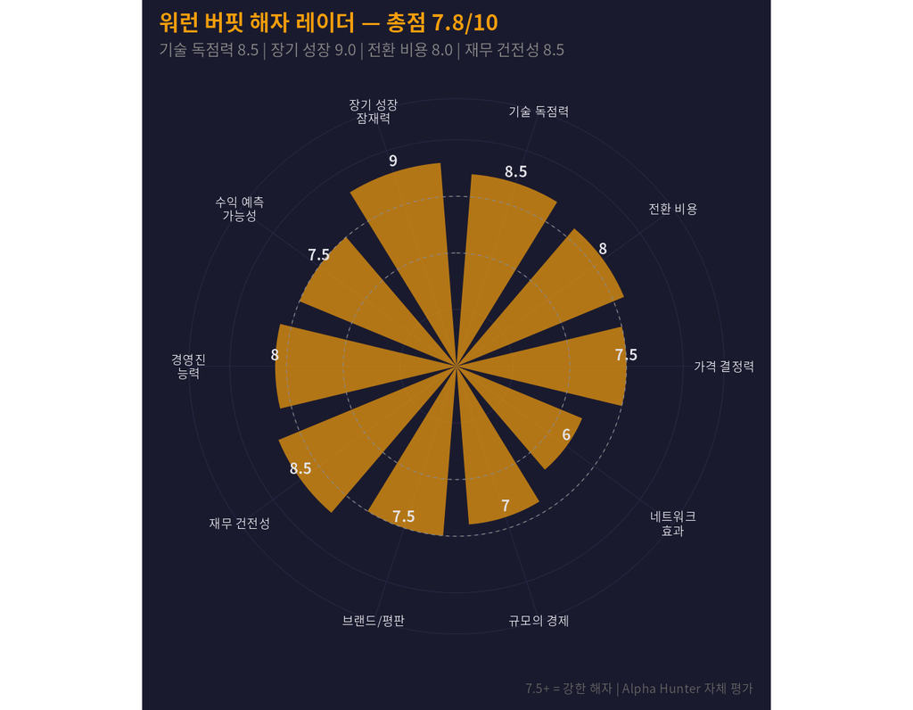

Figure 5: 워런 버핏 해자(Moat) 분석 — 기술 독점 + 전환 비용

### 5.0.1 해자 분석 요약 — 총점 7.8/10

- **기술 독점력 (8.5)**: Dragonfly(패널 검사) + Atlas(계측) + 리소그래피 3대 플랫폼. 어드밴스드 패키징 검사에서 KLA, Camtek과 함께 글로벌 Top 3
- **장기 성장 잠재력 (9.0)**: AI 가속기 + HBM + 2nm GAA → 공정당 검사 강도(inspection intensity) 증가. 구조적 수요 확대
- **전환 비용 (8.0)**: 장비 도입 후 레시피/데이터 축적. 경쟁사로 전환 시 재퀄리파이 6-12개월 소요
- **재무 건전성 (8.5)**: 무차입 경영, 현금 $1B+. 자사주매입 여력 충분

# 6 피터 린치 스토리 점수

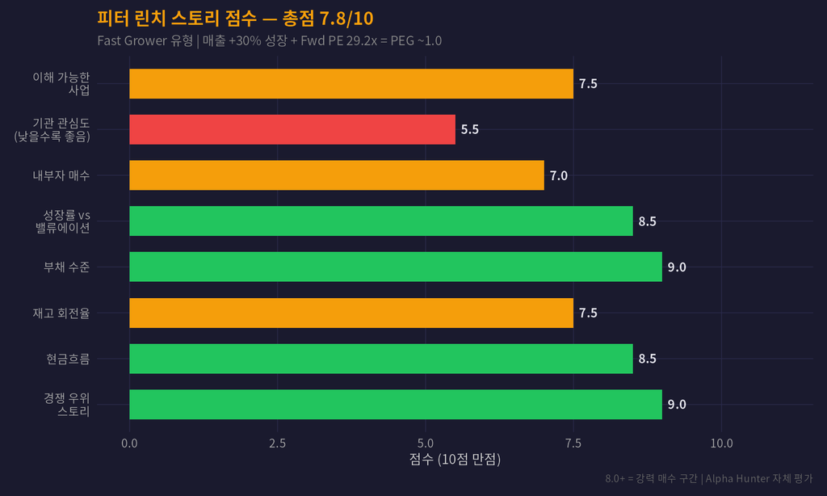

Figure 6: 피터 린치 스토리 점수 — 고속 성장형 히든젬

### 6.0.1 피터 린치 분류 — “Fast Grower”

1. **경쟁 우위 스토리 (9.0)**: 반도체 미세화 + AI/HBM → 검사 강도 구조적 증가. “공정이 복잡해질수록 ONTO가 필요하다”
2. **부채 수준 (9.0)**: 무차입 경영. Net Cash $1B+. 인수에도 건전성 유지
3. **현금흐름 (8.5)**: 높은 마진(GPM 55.7%) + 캐시카우 구조
4. **성장률 vs 밸류에이션 (8.5)**: 매출 +30%, Fwd PE 29.2x. PEG ~1.0은 성장주로서 합리적

# 7 리스크 분석

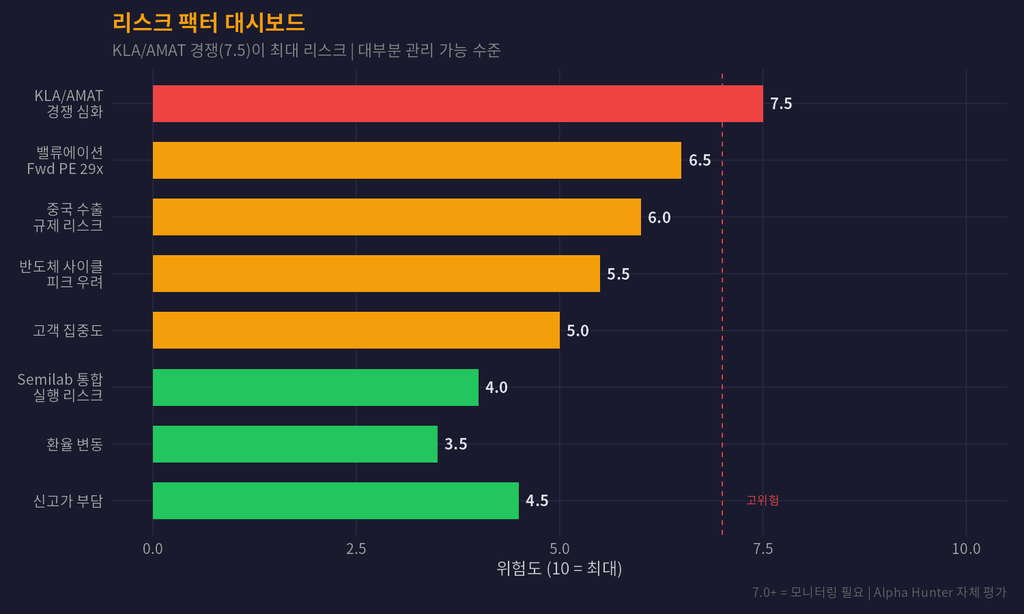

Figure 7: 리스크 팩터 대시보드 — KLA/AMAT 경쟁이 최대 리스크

### 7.0.1 주요 리스크 상세

1. **KLA/AMAT 경쟁 (7.5/10)**: KLA는 매크로 검사와 분석에서 선두. AMAT은 공정 번들링으로 압박. 다만 ONTO는 어드밴스드 패키징 니치에서 강점
2. **밸류에이션 (6.5)**: Fwd PE 29.2x는 성장주로는 합리적이나, 단기 조정 시 하방 압력
3. **중국 수출 규제 (6.0)**: 미중 반도체 제재 강화 시 매출 일부(중국 비중 ~15%) 영향 가능
4. **반도체 사이클 (5.5)**: AI/HBM 사이클은 2027년까지 강세 전망. 조기 피크 리스크는 낮음

# 8 경쟁 구도: ONTO vs KLA vs AMAT

| 항목 | ONTO | KLA | AMAT |
| --- | --- | --- | --- |
| **시총** | $13.8B | $95B | $130B |
| **강점** | 어드밴스드 패키징 | 매크로 검사/분석 | 공정 번들링 |
| **매출 성장** | +30% | +12% | +8% |
| **OPM** | 26.7% | 40.2% | 28.5% |
| **AI/HBM 수혜** | 직접 (Dragonfly) | 간접 | 간접 |
| **주요 고객** | TSMC, 삼성, SK하이닉스 | TSMC, 인텔 | 삼성, TSMC |

ONTO는 시총 대비 성장률이 가장 높고, AI/HBM 어드밴스드 패키징에서 가장 직접적인 수혜를 받는다. KLA 대비 규모는 작지만 **성장 프리미엄**이 정당화된다.

# 9 투자 시나리오

[figure not shown]

Figure 8: 매수/목표/손절 시나리오 — R:R = 1:3.4

### 9.0.1 밸류에이션 근거

**Bull Case ($400, +37.6%)**:

- 2026E 매출 $1.40B, OPM 30%
- Q4 OPM 30% 목표 조기 달성 시
- 애널리스트 최고 목표가 $370 상회

**Bear Case ($268, -7.8%)**:

- AI 투자 사이클 둔화, 매출 +20% 수준
- PE 멀티플 25x 축소

# 10 매수 전략

[output not shown]

## 10.1 카탈리스트 일정

- **Q2 2026 가이던스**: $320-330M (역대 최고 경신 예상)
- **Q2 실적발표 (8월)**: OPM 28%+ 확인 시 멀티플 리레이팅
- **TSMC CoWoS 증설**: Dragonfly G5 추가 수주 기대
- **HBM4 양산**: 검사/계측 강도 증가 → ASP 상승
- **Semilab + Rigaku 협업**: 포트폴리오 시너지 본격화

# 11 결론

> **ONTO Innovation은 “AI 시대의 검사/계측 인프라 독점자”다.**

## 11.1 핵심 투자 근거 3줄 요약

**면책 문구**

이 프로젝트는 가상 투자 시뮬레이션 목적으로 작성되었습니다. 실제 투자 권유가 아니며, 모든 투자 결정은 개인의 판단과 책임 하에 이루어져야 합니다.